# TORC1関連因子遺伝子破壊株におけるAde4-GFP foci形成の観察

MT

2022-05-24

# 1 この事例で扱うデータと統計

**カテゴリ変数**：遺伝型を表す `strain`  
**数値変数**： 顆粒を持つ細胞の割合（%）`pct_foci_cell`  
**グラフ**：棒グラフ（平均） + エラーバー（1SD） + ドットプロット（各データポイント）  
**統計**：無し

# 2 データの取得と読み込み

既知のTORC1の上流および下流因子の遺伝子破壊株におけるAde4-yeGFP顆粒形成効率を測定する。細胞をアデニン無しの培地に移してAde4-GFP fociを形成させて蛍光顕微鏡観察。画像処理により顆粒を持つ細胞の割合を計測し、結果をExcelファイルにまとめた。

```r
library(pacman) # パッケージをまとめてロード
p_load(tidyverse, openxlsx, readxl, ggtext, multcomp, ggsignif, knitr, nparcomp, rstatix, dunn.test)
```

```r
mutant_foci <- read_excel("concat_201112.xlsx",
                          col_types = c("skip", "skip", "skip",
                                        "skip", "skip", "text", "skip", "text",
                                        "numeric"))
mutant_foci <- mutant_foci %>%
  filter(cr_pct_foci_cell !="") ## NAのデータを除く
mutant_class <- read_excel("torc1_mut_classification.xlsx")  ## TORC1との関係性のデータ
```

# 3 データの集計

視野内で顆粒を持つ細胞の割合（%）を表す変数`cr_pct_foci_cell`の平均とSDを求める。また1ｘSDに相当するerror barを書くための範囲を設定。結果をExcelファイルとして保存。

```r
mean_sd <- mutant_foci %>%
  group_by(strain) %>%
  summarise(meanfoci = mean(cr_pct_foci_cell), sdfoci = sd(cr_pct_foci_cell))
# mean_sd <- arrange(mean_sd, meanfoci) # データをソート
```

TORC1との関連性を表す変数`signaling`を`left_join`で導入する。

```r
mean_sd <- mean_sd %>%
  left_join(mutant_class, by = "strain")
mutant_foci <- mutant_foci %>%
  left_join(mutant_class, by = "strain")
write.xlsx(mean_sd, "220524_torc1mut_mean_sd.xlsx", colNames = TRUE, sheetName = "220524_torc1mut")
```

無関係なreg1∆のデータを取り除く。またwtのデータを抽出しておく。

```r
mean_sd <- mean_sd %>%
  filter(strain !="reg1") # reg1のデータを除く
mutant_foci <- mutant_foci %>%
  filter(strain !="reg1") # reg1のデータを除く
mean_wt <- mean_sd %>%
  filter(strain == "wt") # wtのデータを抽出しておく
```

# 4 データの可視化

顆粒を持つ細胞の割合の平均値を棒グラフで、1SDをエラーバーで描画。個々のデータ点もプロット。プロットの縦軸と横軸を入れ替える。

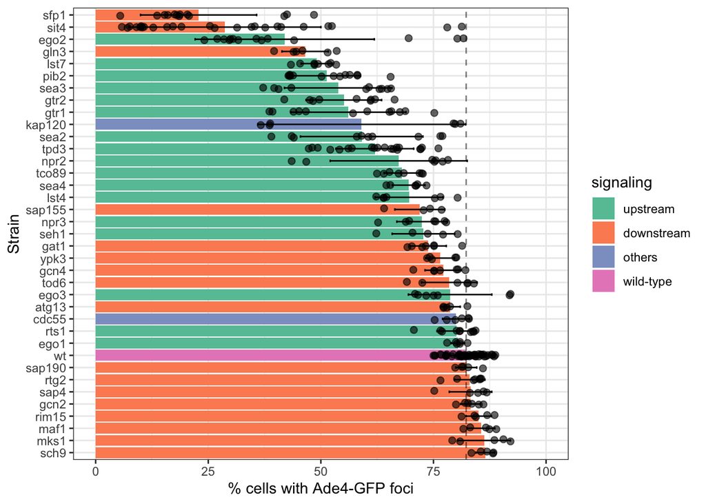

```r
plot1 <- ggplot(mean_sd, aes (x = reorder(x =strain, -meanfoci), y = meanfoci)) + # strainを -meanfociで並べ変える、すなわち逆順
  geom_bar(aes(fill = signaling), stat = "identity")+  # TORC1との関係性に応じてバーの色を変える
  # geom_errorbarで標準偏差を描く
  geom_errorbar(mapping = aes(ymin = meanfoci - sdfoci, ymax = meanfoci + sdfoci, width = 0.2)) +
  geom_jitter(mutant_foci, mapping = aes (x= reorder(x = strain, X = -cr_pct_foci_cell, FUN = mean), y = cr_pct_foci_cell), size =2,
              color = 'black', alpha =0.6, height = 0, width = 0.1)+ # jitterで適当に点を散らす
  geom_hline(yintercept = mean_wt$meanfoci, linetype = 2, alpha=0.5)+  # wtの平均値を点線で表す
  # 凡例の表示順を変えて、fillの色も変える
  scale_fill_brewer(palette = "Set2",limits = c("upstream","downstream","others","wild-type")) +
  ylab("% cells with Ade4-GFP foci") +
  xlab("Strain")+
  ylim(0 ,100) + # % cells with fociの値の範囲を設定
  theme_bw() +
  coord_flip()　# 軸を入れ替える
plot1
```

```r
mean_sd$strain  # 最初はstrainは文字型
```

```
##  [1] "atg13"  "cdc55"  "ego1"   "ego2"   "ego3"   "gat1"   "gcn2"   "gcn4"
##  [9] "gln3"   "gtr1"   "gtr2"   "kap120" "lst4"   "lst7"   "maf1"   "mks1"
## [17] "npr2"   "npr3"   "pib2"   "rim15"  "rtg2"   "rts1"   "sap155" "sap190"
## [25] "sap4"   "sch9"   "sea2"   "sea3"   "sea4"   "seh1"   "sfp1"   "sit4"
## [33] "tco89"  "tod6"   "tpd3"   "wt"     "ypk3"
```

```r
levels(mean_sd$strain)
```

[output not shown]

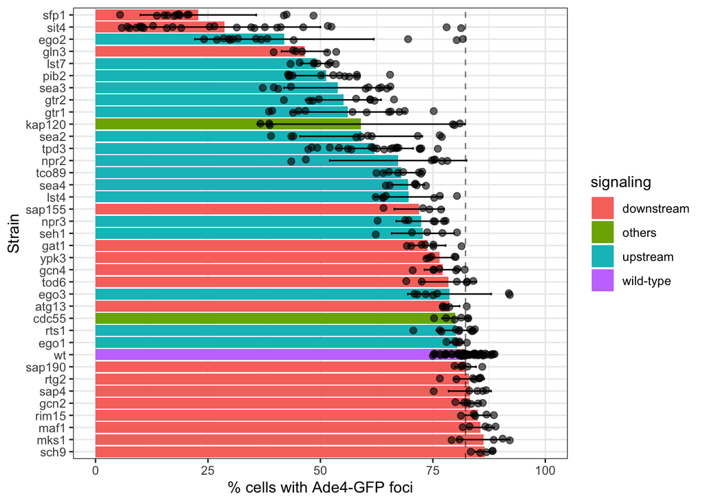

```r
mean_sd <- mean_sd %>%
  arrange(desc(meanfoci))
mean_sd$strain <- as_factor(mean_sd$strain)

plot2 <- mean_sd %>%
  ggplot(aes(x =strain, y = meanfoci)) +
  geom_bar(aes(fill = signaling), stat = "identity")+  # TORC1との関係性に応じてバーの色を変える
  # geom_errorbarで標準偏差を描く
  geom_errorbar(mapping = aes(ymin = meanfoci - sdfoci, ymax = meanfoci + sdfoci, width = 0.2)) +
    geom_jitter(mutant_foci, mapping = aes(x = strain, y = cr_pct_foci_cell), size =2,
              color = 'black', alpha =0.6, height = 0, width = 0.1) +
  geom_hline(yintercept = mean_wt$meanfoci, linetype = 2, alpha=0.5) +
  # 凡例の表示順を変えて、fillの色も変える
  # scale_fill_brewer(palette = "Set2",limits = c("upstream","downstream","others","wild-type")) +
  ylab("% cells with Ade4-GFP foci") +
  xlab("Strain") +
  ylim(0 ,100) +
  theme_bw() +
  coord_flip()
plot2
```